# Time Series Analysis and Forecasting

March 11, 2018

```python
# import packages
import pandas as pd
import seaborn as sns
import matplotlib.pyplot as plt
%matplotlib inline
import datetime as dt
import numpy as np
import warnings
from statsmodels.graphics.tsaplots import plot_acf, plot_pacf
import statsmodels.api as sm

np.warnings.filterwarnings('ignore')
```

```python
# read data and set date as index
coins = pd.read_csv("http://data.oscarsouth.com/coins/coins.csv", index_col = 'Date')
coins.index = pd.to_datetime(coins.index)
```

```python
# view data
coins.info()
```

```
<class 'pandas.core.frame.DataFrame'>
DatetimeIndex: 2287 entries, 2011-12-18 to 2018-03-22
Data columns (total 21 columns):
BTC_weighted_price    2287 non-null float64
BTC_volume            2287 non-null float64
BTC_open              2287 non-null float64
BTC_high              2287 non-null float64
BTC_low               2287 non-null float64
BTC_close             2287 non-null float64
BTC_pcnt_change       2287 non-null float64
ETH_weighted_price    956 non-null float64
ETH_volume            956 non-null float64
ETH_open              956 non-null float64
ETH_high              956 non-null float64
ETH_low               956 non-null float64
ETH_close             956 non-null float64
ETH_pcnt_change       956 non-null float64
LTC_weighted_price    1523 non-null float64
LTC_volume            1523 non-null float64
LTC_open              1523 non-null float64
LTC_high              1523 non-null float64
LTC_low               1523 non-null float64
LTC_close             1523 non-null float64
LTC_pcnt_change       1523 non-null float64
dtypes: float64(21)
memory usage: 393.1 KB
```

```python
coins.head()
```

| Date | BTC_weighted_price | BTC_volume | BTC_open | BTC_high | BTC_low | BTC_close | BTC_pcnt_change | ETH_weighted_price | ETH_volume | ETH_open | ... | ETH_low | ETH_close | ETH_pcnt_change | LTC_weighted_price | LTC_volume | LTC_open | LTC_high | LTC_low | LTC_close | LTC_pcnt_change |
| --- | --- | --- | --- | --- | --- | --- | --- | --- | --- | --- | --- | --- | --- | --- | --- | --- | --- | --- | --- | --- | --- |
| 2011-12-18 | 3.397929 | 17.242857 | 3.25 | 3.50 | 3.25 | 3.50 | 7.692308 | NaN | NaN | NaN | ... | NaN | NaN | NaN | NaN | NaN | NaN | NaN | NaN | NaN | NaN |
| 2011-12-19 | 3.809668 | 134.734292 | 3.50 | 3.98 | 3.50 | 3.85 | 10.000000 | NaN | NaN | NaN | ... | NaN | NaN | NaN | NaN | NaN | NaN | NaN | NaN | NaN | NaN |
| 2011-12-20 | 4.570030 | 94.743353 | 4.75 | 4.75 | 4.53 | 4.55 | -4.210526 | NaN | NaN | NaN | ... | NaN | NaN | NaN | NaN | NaN | NaN | NaN | NaN | NaN | NaN |
| 2011-12-21 | 4.380000 | 20.899543 | 4.38 | 4.38 | 4.38 | 4.38 | 0.000000 | NaN | NaN | NaN | ... | NaN | NaN | NaN | NaN | NaN | NaN | NaN | NaN | NaN | NaN |
| 2011-12-22 | 4.183819 | 8.535264 | 4.19 | 4.19 | 4.17 | 4.17 | -0.477327 | NaN | NaN | NaN | ... | NaN | NaN | NaN | NaN | NaN | NaN | NaN | NaN | NaN | NaN |

5 rows × 21 columns

```python
coins.tail()
```

| Date | BTC_weighted_price | BTC_volume | BTC_open | BTC_high | BTC_low | BTC_close | BTC_pcnt_change | ETH_weighted_price | ETH_volume | ETH_open | ... | ETH_low | ETH_close | ETH_pcnt_change | LTC_weighted_price | LTC_volume | LTC_open | LTC_high | LTC_low | LTC_close | LTC_pcnt_change |
| --- | --- | --- | --- | --- | --- | --- | --- | --- | --- | --- | --- | --- | --- | --- | --- | --- | --- | --- | --- | --- | --- |
| 2018-03-18 | 7670.518666 | 17695.486956 | 7851.8800 | 8294.4275 | 7316.2200 | 8190.5225 | 4.312884 | 501.397260 | 4303.161798 | 549.121228 | ... | 452.386465 | 572.804191 | 28.535656 | 145.516719 | 705.795075 | 151.878758 | 163.287832 | 135.373116 | 158.429113 | 13.668707 |
| 2018-03-19 | 8383.159592 | 15669.313725 | 8194.8500 | 8745.4450 | 8101.6200 | 8597.9475 | 4.918912 | 541.675929 | 1790.971784 | 537.459237 | ... | 512.341345 | 563.896387 | 6.728342 | 156.570679 | 351.514465 | 153.643768 | 165.783378 | 149.879970 | 161.201370 | -0.947385 |
| 2018-03-20 | 8687.915179 | 12356.075702 | 8594.9325 | 9043.6450 | 8315.0900 | 8916.1350 | 3.737115 | 547.002868 | 1216.876779 | 556.092047 | ... | 516.165864 | 576.873845 | 12.135824 | 164.045909 | 358.617035 | 161.334017 | 174.117116 | 154.619348 | 167.363254 | -3.533202 |
| 2018-03-21 | 8965.557594 | 10624.202171 | 8917.4800 | 9181.2250 | 8754.9675 | 8893.9325 | -0.264060 | 567.331788 | 1446.754033 | 558.457274 | ... | 542.807810 | 556.982612 | 0.130064 | 170.527774 | 290.808030 | 168.941659 | 176.695797 | 163.424513 | 168.495551 | 0.006967 |
| 2018-03-22 | 8752.489005 | 9798.694309 | 8891.8750 | 9096.8975 | 8486.3125 | 8706.0225 | -2.090138 | 541.801213 | 1128.149649 | 559.610153 | ... | 515.641926 | 547.913526 | -3.621886 | 165.638929 | 186.969877 | 168.500853 | 174.660432 | 158.701087 | 164.978952 | -1.891697 |

5 rows × 21 columns

# Plotting Time Series

1. Bitcoin, Ethereum and Litecoin Weighted Price
2. Bitcoin Weighted Price
3. Ethereum Weighted Price
4. Litecoin Weighted Price

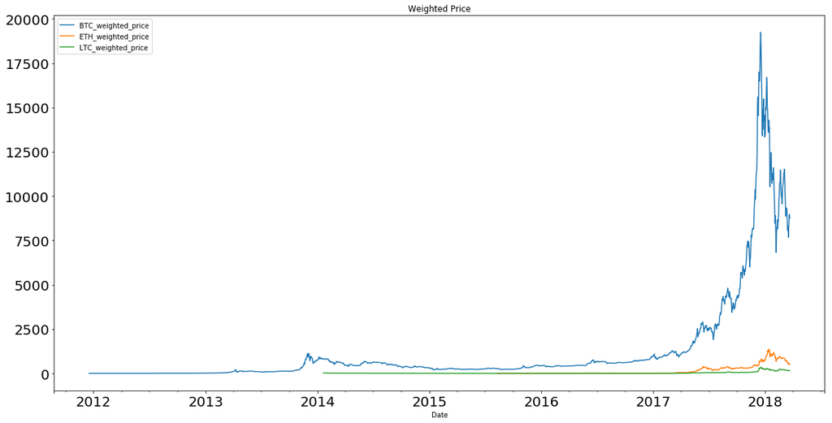

```python
coins.filter(regex = "weighted_price").plot(figsize=(20,10), fontsize=20, title='Weighted Price')
```

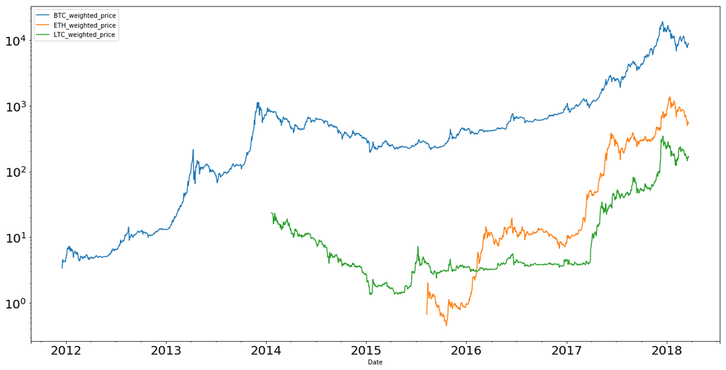

```python
coins.filter(regex = "weighted_price").plot(figsize=(20,10), fontsize=20, logy=True)
```

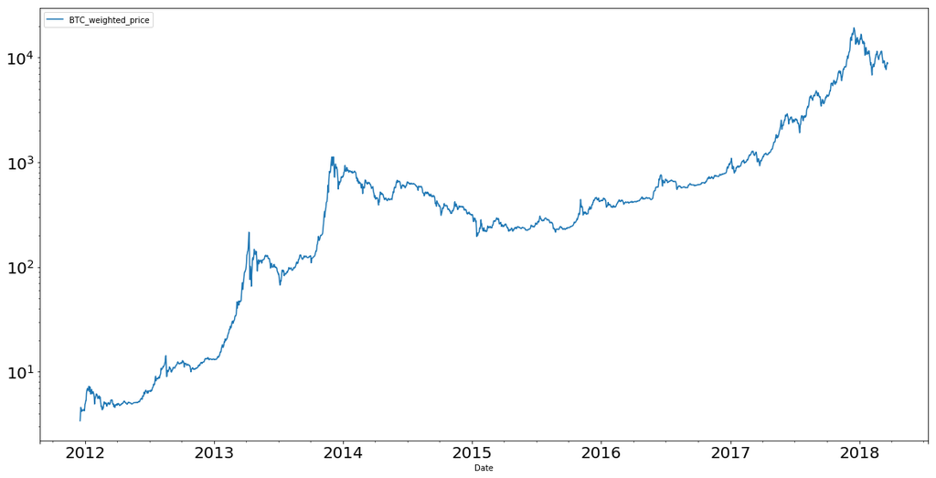

```python
coins.filter(regex = "BTC_weighted_price").plot(figsize=(20,10), fontsize=20, logy=True).legend(loc = 2)
```

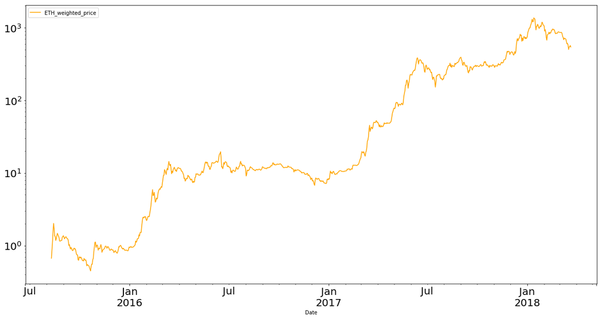

```python
coins.filter(regex = "ETH_weighted_price").plot(figsize=(20,10), fontsize=20, color="orange", logy=True).legend(loc = 2)
```

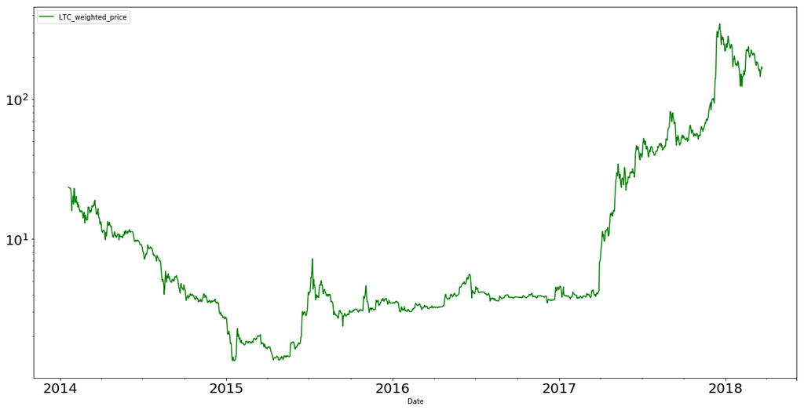

```python
coins.filter(regex = "LTC_weighted_price").plot(figsize=(20,10), fontsize=20, color="green", logy=True).legend(loc = 2)
```

# Candlestick

1. Bitcoin
2. Ethereum
3. Litecoin

```python
from matplotlib import style
from matplotlib.finance import candlestick_ohlc
import matplotlib.dates as mdates

btc_ohlc = coins[['BTC_open', 'BTC_high', 'BTC_low', 'BTC_close']]

def cs_plot(btc_ohlc, title=''):
    btc_ohlc.reset_index(inplace=True)
    btc_ohlc["Date"] = btc_ohlc["Date"].map(mdates.date2num)

    fig = plt.figure(figsize=(20,10))
    f1 = plt.subplot2grid((1, 1), (0, 0))
    f1.xaxis_date()
    candlestick_ohlc(f1, btc_ohlc.values, width=0.5, colorup='g', colordown='#ff1717')

    plt.ylabel('Price')
    plt.xlabel('Date')
    plt.title(title)
    return
```

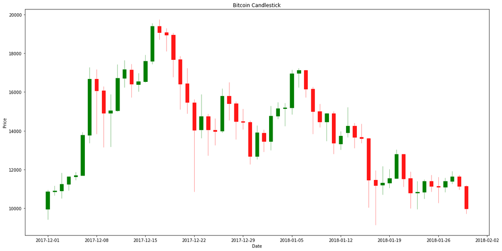

```python
btc_ohlc = coins[['BTC_open', 'BTC_high', 'BTC_low', 'BTC_close']]
btc_ohlc = btc_ohlc.loc['20171201':'20180130']
cs_plot(btc_ohlc, title='Bitcoin Candlestick')
```

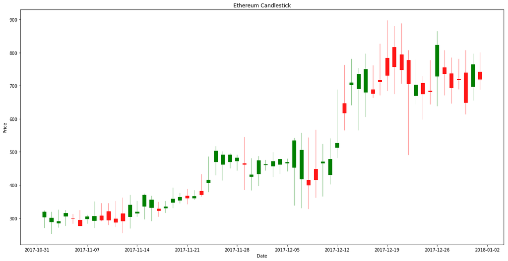

```python
eth_ohlc = coins[['ETH_open', 'ETH_high', 'ETH_low', 'ETH_close']]

eth_ohlc = eth_ohlc.loc['20171101':'20180101']
cs_plot(eth_ohlc, title='Ethereum Candlestick')
```

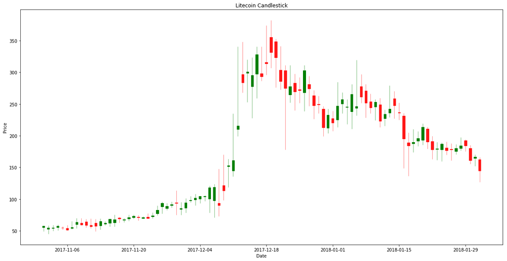

```python
ltc_ohlc = coins[['LTC_open', 'LTC_high', 'LTC_low', 'LTC_close']]
ltc_ohlc = ltc_ohlc.loc['20171101':'20180201']

cs_plot(ltc_ohlc, title='Litecoin Candlestick')
```

# Identifying Trend Pattern

1. Bitcoin Rolling Mean & Standard Deviation
2. Ethereum Rolling Mean & Standard Deviation
3. Litecoin Rolling Mean & Standard Deviation

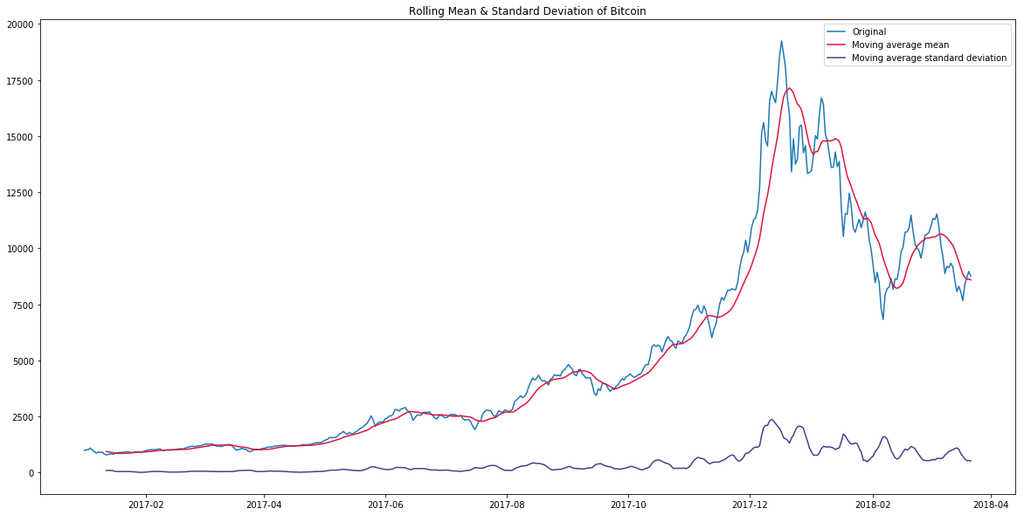

```python
wp_btc = coins['BTC_weighted_price']
wp_btc = wp_btc['20170101':]

def plot_rolling_average(wp_btc, title='Rolling Mean & Standard Deviation of Bitcoin'):

    #calculate moving averages
    rolling_mean = wp_btc.rolling(window=12,center=False).mean()
    rolling_std = wp_btc.rolling(window=12,center=False).std()

    #plot statistics
    fig = plt.figure(figsize=(20,10))
    plt.plot(wp_btc, label='Original')
    plt.plot(rolling_mean, color='crimson', label='Moving average mean')
    plt.plot(rolling_std, color='darkslateblue', label='Moving average standard deviation')
    plt.legend(loc='best')
    plt.title(title)

plot_rolling_average(wp_btc)
```

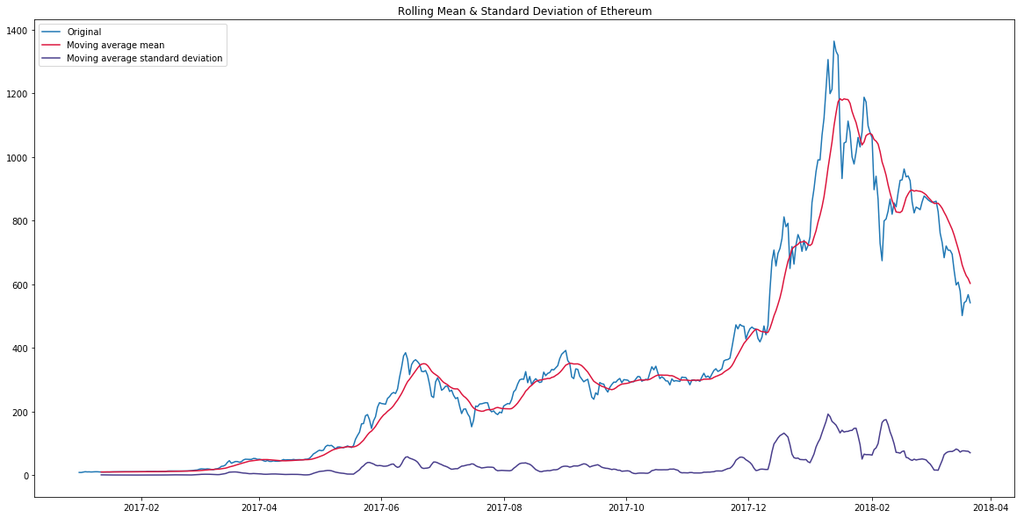

```python
wp_eth = coins['ETH_weighted_price']
wp_eth = wp_eth['20170101':]

plot_rolling_average(wp_eth, title='Rolling Mean & Standard Deviation of Ethereum')
```

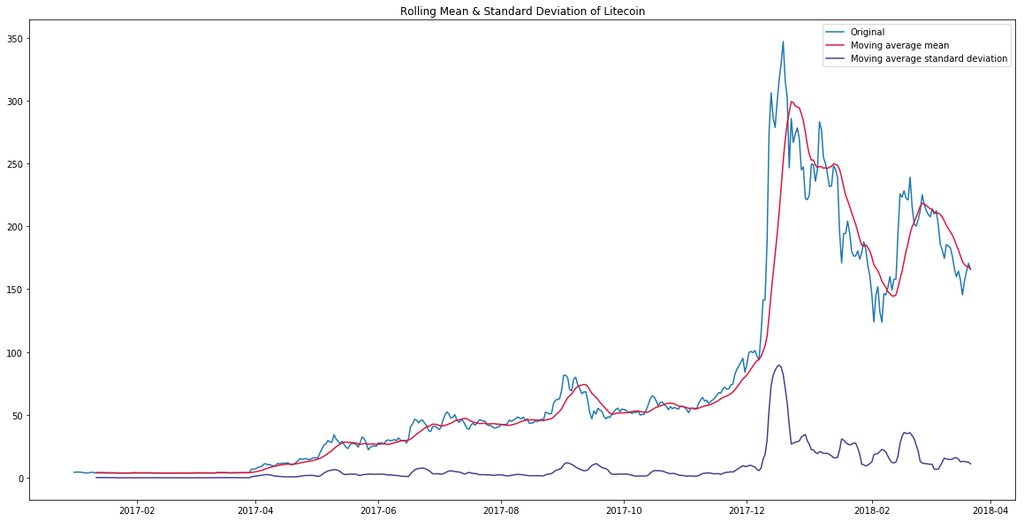

```python
wp_ltc = coins['LTC_weighted_price']
wp_ltc = wp_ltc['20170101':]

plot_rolling_average(wp_ltc, title='Rolling Mean & Standard Deviation of Litecoin')
```

# Stationarity

Augmented Dickey-Fuller Test will be used to check for stationarity of the time-series

### Bitcoin Weighted Price

Hypothesis Testing  
H0: The time series is non-stationary  
H1: The time series is stationary

```python
from statsmodels.tsa.stattools import adfuller, kpss

def test_stationarity(wp_btc):
    print ('Results of Dickey-Fuller Test:')
    dftest = adfuller(wp_btc, autolag='AIC' )
    dfoutput = pd.Series(dftest[0:4], index=['Test Statistic','p-value','#Lags Used','Number of Observations Used'])
    for key,value in dftest[4].items():
        dfoutput['Critical Value (%s)'%key] = value
    print (dfoutput)


test_stationarity(wp_btc)
```

```
Results of Dickey-Fuller Test:
Test Statistic                  -1.150957
p-value                          0.694329
#Lags Used                       1.000000
Number of Observations Used    444.000000
Critical Value (1%)             -3.445164
Critical Value (5%)             -2.868072
Critical Value (10%)            -2.570249
dtype: float64
```

As the p-value is greater than 0.05, we cannot reject null hypothesis, the series is not stationary

### Ethereum Weighted Price

```python
test_stationarity(wp_eth)
```

```
Results of Dickey-Fuller Test:
Test Statistic                  -1.066372
p-value                          0.728294
#Lags Used                      12.000000
Number of Observations Used    433.000000
Critical Value (1%)             -3.445543
Critical Value (5%)             -2.868238
Critical Value (10%)            -2.570338
dtype: float64
```

As the p-value is greater than 0.05, we cannot reject null hypothesis, the series is not stationary

### Litecoin Weighted Price

```python
test_stationarity(wp_ltc)
```

```
Results of Dickey-Fuller Test:
Test Statistic                  -1.206902
p-value                          0.670619
#Lags Used                      18.000000
Number of Observations Used    427.000000
Critical Value (1%)             -3.445758
Critical Value (5%)             -2.868333
Critical Value (10%)            -2.570388
dtype: float64
```

As the p-value is greater than 0.05, we cannot reject null hypothesis, the series is not stationary

# Eliminating Trend and Seasonality

From the preliminary plots, an increasing trend can be seen for all cryptocurrencies especially starting in 2017.

There are two methods that can be used to remove trend and seasonality:

1. **Differencing**
2. **Decomposition**

These methods will be applied to Bitcoin, Ethereum and Litecoin.

**ts_diagnostics** is a function created to monitor the progress in making the time-series stationary.

```python
def ts_diagnostics(wp_btc, lags=None, title=''):

    if not isinstance(wp_btc, pd.Series):
        wp_btc = pd.Series(wp_btc)

    # weekly moving averages (5 day window because of workdays)
    rolling_mean = wp_btc.rolling(window=12,center=False).mean()
    rolling_std = wp_btc.rolling(window=12,center=False).std()

    fig = plt.figure(figsize=(14, 12))
    layout = (3, 2)
    ts_ax = plt.subplot2grid(layout, (0, 0), colspan=2)
    acf_ax = plt.subplot2grid(layout, (1, 0))
    pacf_ax = plt.subplot2grid(layout, (1, 1))
    qq_ax = plt.subplot2grid(layout, (2, 0))
    hist_ax = plt.subplot2grid(layout, (2, 1))

    # time series plot
    wp_btc.plot(ax=ts_ax)
    rolling_mean.plot(ax=ts_ax, color='crimson');
    rolling_std.plot(ax=ts_ax, color='darkslateblue');
    ts_ax.set_title(title, fontsize=24);

    # acf and pacf
    plot_acf(wp_btc, lags=lags, ax=acf_ax, alpha=0.5)
    plot_pacf(wp_btc, lags=lags, ax=pacf_ax, alpha=0.5)

    # qq plot
    sm.qqplot(wp_btc, line='s', ax=qq_ax)
    qq_ax.set_title('QQ Plot')

    # hist plot
    wp_btc.plot(ax=hist_ax, kind='hist', bins=25);
    hist_ax.set_title('Histogram');
    plt.tight_layout();
    plt.show()

    # perform Augmented Dickey Fuller test
    print('Results of Dickey-Fuller test:')
    dftest = adfuller(wp_btc, autolag='AIC')
    dfoutput = pd.Series(dftest[0:4], index=['test statistic', 'p-value', '# of lags', '# of observations'])
    for key, value in dftest[4].items():
        dfoutput['Critical Value (%s)'%key] = value
    print(dfoutput)
    return
```

# Differencing

1. First-Order Difference
2. Stationary in Variance
3. Log-Transformed First-Order
4. Second-Order Difference

## Bitcoin: First-Order Difference

Removing the trend from time-series using first order differencing.

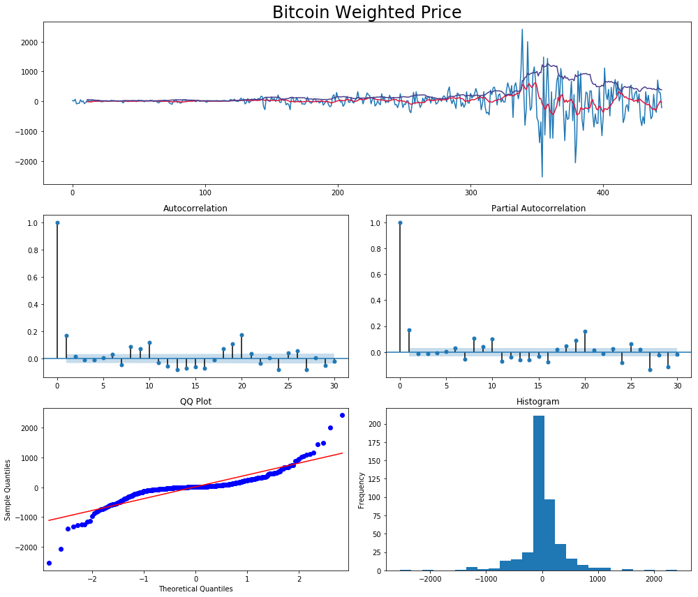

```
Results of Dickey-Fuller test:
test statistic         -1.772602e+01
p-value                 3.451501e-30
# of lags               0.000000e+00
# of observations       4.440000e+02
Critical Value (1%)    -3.445164e+00
Critical Value (5%)    -2.868072e+00
Critical Value (10%)   -2.570249e+00
dtype: float64
```

```python
wp_btc_diff = np.diff(wp_btc)

ts_diagnostics(wp_btc_diff, lags=30, title='Bitcoin Weighted Price')
```

## Bitcoin: Stationary in Variance

Using log transformation to make the variance of the time-series stationary.

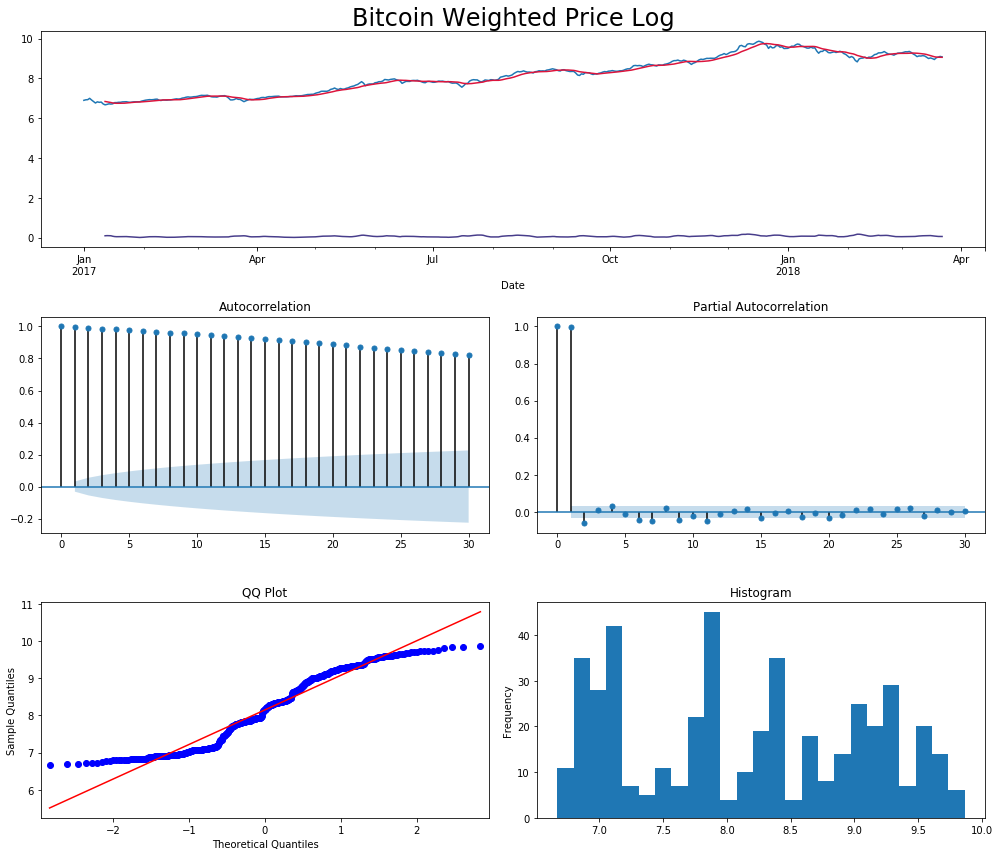

```
Results of Dickey-Fuller test:
test statistic           -0.931620
p-value                   0.777381
# of lags                 1.000000
# of observations       444.000000
Critical Value (1%)      -3.445164
Critical Value (5%)      -2.868072
Critical Value (10%)     -2.570249
dtype: float64
```

```python
wp_btc_log = np.log(wp_btc)

ts_diagnostics(wp_btc_log, lags=30, title='Bitcoin Weighted Price Log')
```

## Bitcoin: Log-Transformed First-Order

Combining both techniques

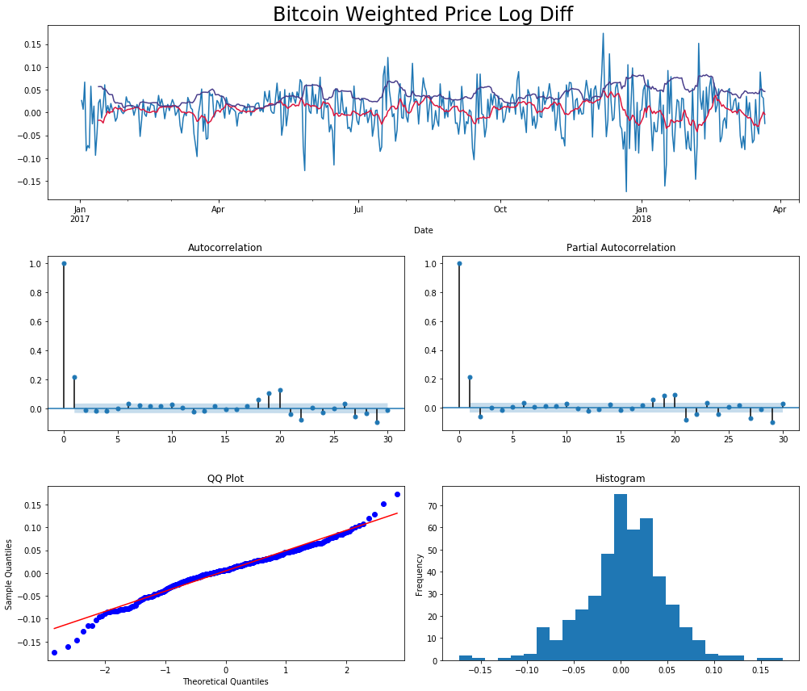

```
Results of Dickey-Fuller test:
test statistic         -1.691738e+01
p-value                 1.000031e-29
# of lags               0.000000e+00
# of observations       4.440000e+02
Critical Value (1%)    -3.445164e+00
Critical Value (5%)    -2.868072e+00
Critical Value (10%)   -2.570249e+00
dtype: float64
```

```python
wp_btc_log_diff = np.log(wp_btc).diff().dropna()

ts_diagnostics(wp_btc_log_diff, lags=30, title='Bitcoin Weighted Price Log Diff')
```

## Bitcoin: Second-Order Difference

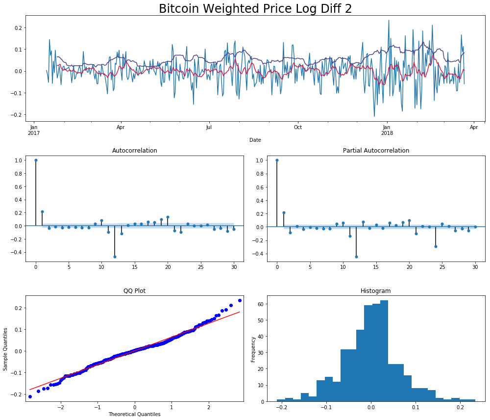

```
Results of Dickey-Fuller test:
test statistic         -8.571430e+00
p-value                 8.177609e-14
# of lags               1.200000e+01
# of observations       4.200000e+02
Critical Value (1%)    -3.446016e+00
Critical Value (5%)    -2.868446e+00
Critical Value (10%)   -2.570449e+00
dtype: float64
```

```python
wp_btc_log_diff2 = np.log(wp_btc).diff().diff(12).dropna()

ts_diagnostics(wp_btc_log_diff2, lags=30, title='Bitcoin Weighted Price Log Diff 2')
```

# Decomposition

Both trend and seasonality are modelled separately.

**ts_decomposition** function is created for this purpose.

```python
from statsmodels.tsa.seasonal import seasonal_decompose

def ts_decomposition(wp_btc, title=''):
    decomposition = seasonal_decompose(wp_btc)

    trend = decomposition.trend
    seasonal = decomposition.seasonal
    residual = decomposition.resid

    fig = plt.figure(figsize=(14, 12))
    layout = (4, 1)

    #plot original
    plt.subplot(411)
    plt.plot(wp_btc, label='Original')
    plt.legend(loc='best')
    plt.title(title, fontsize=24)

    #plot trend
    plt.subplot(412)
    plt.plot(trend, label='Trend')
    plt.legend(loc='best')

    #plot seasonality
    plt.subplot(413)
    plt.plot(seasonal,label='Seasonality')
    plt.legend(loc='best')

    #plot residuals
    plt.subplot(414)
    plt.plot(residual, label='Residuals')
    plt.legend(loc='best')
    plt.tight_layout()
    return
```

## Bitcoin: Decomposition

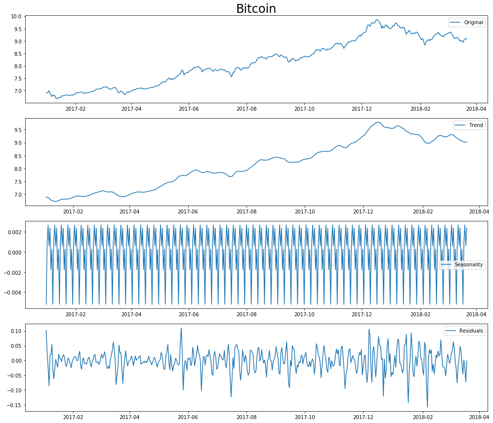

```python
ts_decomposition(wp_btc_log, title='Bitcoin')
```

**Test of stationarity using time-series residual**

```python
btc_decomposition = seasonal_decompose(wp_btc_log)
btc_residual = btc_decomposition.resid

wp_btc_log_decompose = btc_residual
wp_btc_log_decompose.dropna(inplace=True)
test_stationarity(wp_btc_log_decompose)
```

```
Results of Dickey-Fuller Test:
Test Statistic                -9.099881e+00
p-value                        3.629791e-15
#Lags Used                     1.600000e+01
Number of Observations Used    4.230000e+02
Critical Value (1%)           -3.445904e+00
Critical Value (5%)           -2.868397e+00
Critical Value (10%)          -2.570423e+00
dtype: float64
```

## Ethereum: First-Order Difference

Removing the trend from time-series using first order differencing.

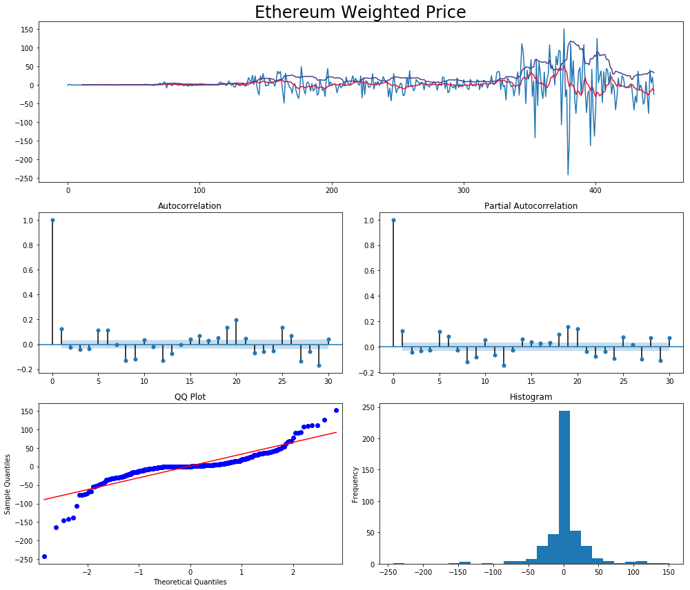

```
Results of Dickey-Fuller test:
test statistic           -3.342815
p-value                   0.013070
# of lags                18.000000
# of observations       426.000000
Critical Value (1%)      -3.445794
Critical Value (5%)      -2.868349
Critical Value (10%)     -2.570397
dtype: float64
```

```python
wp_eth_diff = np.diff(wp_eth)

ts_diagnostics(wp_eth_diff, lags=30, title='Ethereum Weighted Price')
```

## Ethereum: Stationary in Variance

Using log transformation to make the variance of the time-series stationary.

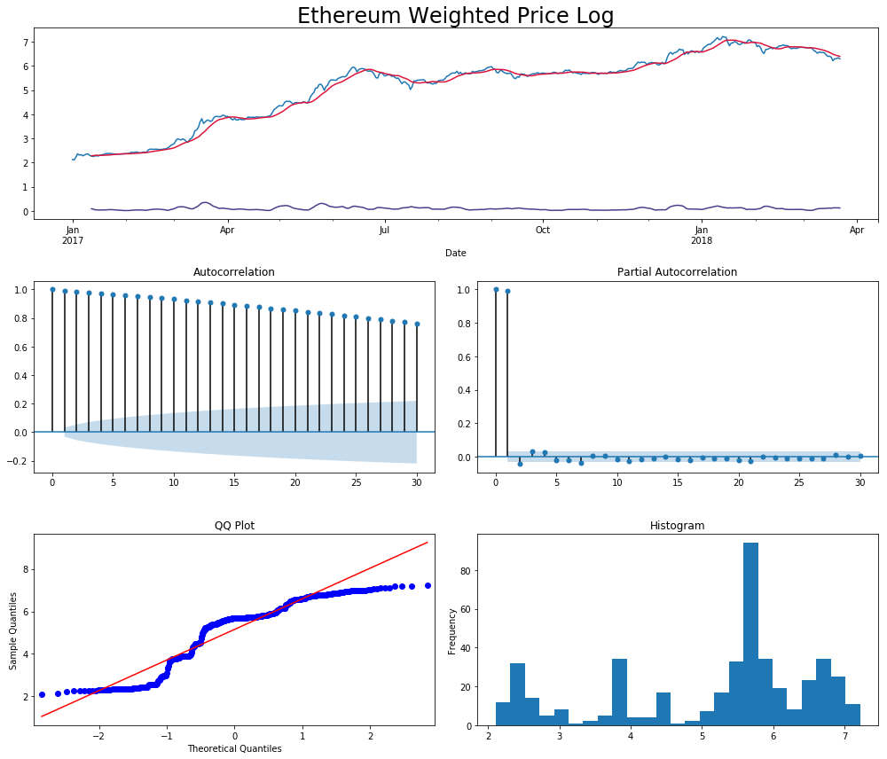

```
Results of Dickey-Fuller test:
test statistic           -2.337641
p-value                   0.160115
# of lags                 1.000000
# of observations       444.000000
Critical Value (1%)      -3.445164
Critical Value (5%)      -2.868072
Critical Value (10%)     -2.570249
dtype: float64
```

```python
wp_eth_log = np.log(wp_eth)

ts_diagnostics(wp_eth_log, lags=30, title='Ethereum Weighted Price Log')
```

## Ethereum: Log-Transformed First-Order

Combining both techniques

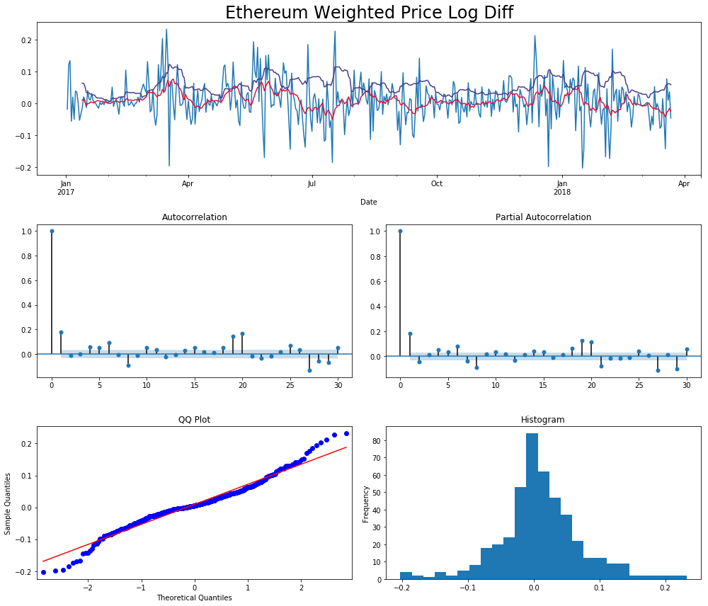

```
Results of Dickey-Fuller test:
test statistic         -1.749378e+01
p-value                 4.422566e-30
# of lags               0.000000e+00
# of observations       4.440000e+02
Critical Value (1%)    -3.445164e+00
Critical Value (5%)    -2.868072e+00
Critical Value (10%)   -2.570249e+00
dtype: float64
```

```python
wp_eth_log_diff = np.log(wp_eth).diff().dropna()

ts_diagnostics(wp_eth_log_diff, lags=30, title='Ethereum Weighted Price Log Diff')
```

## Ethereum: Second-Order Difference

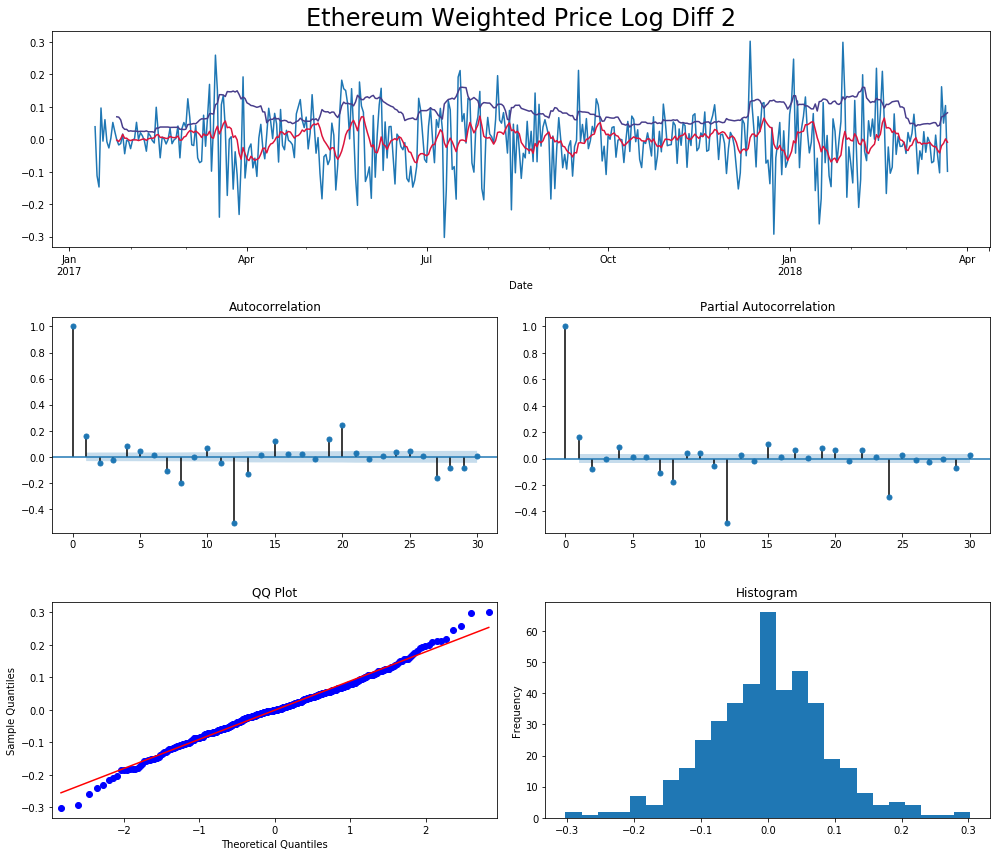

```
Results of Dickey-Fuller test:
test statistic         -7.105903e+00
p-value                 4.054526e-10
# of lags               1.400000e+01
# of observations       4.180000e+02
Critical Value (1%)    -3.446091e+00
Critical Value (5%)    -2.868479e+00
Critical Value (10%)   -2.570466e+00
dtype: float64
```

```python
wp_eth_log_diff2 = np.log(wp_eth).diff().diff(12).dropna()

ts_diagnostics(wp_eth_log_diff2, lags=30, title='Ethereum Weighted Price Log Diff 2')
```

## Ethereum: Decomposition

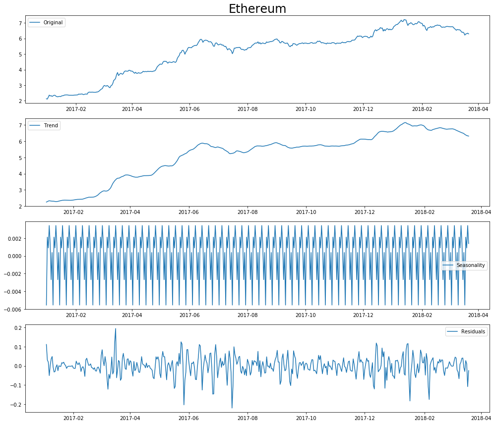

```python
wp_eth_log = np.log(wp_eth)

ts_decomposition(wp_eth_log, title='Ethereum')
```

**Test of stationarity using time-series residual**

```python
eth_decomposition = seasonal_decompose(wp_eth_log)
eth_residual = eth_decomposition.resid

wp_eth_log_decompose = eth_residual
wp_eth_log_decompose.dropna(inplace=True)
test_stationarity(wp_eth_log_decompose)
```

```
Results of Dickey-Fuller Test:
Test Statistic                -9.714631e+00
p-value                        9.905086e-17
#Lags Used                     1.600000e+01
Number of Observations Used    4.230000e+02
Critical Value (1%)           -3.445904e+00
Critical Value (5%)           -2.868397e+00
Critical Value (10%)          -2.570423e+00
dtype: float64
```

## Litecoin: First-Order Difference

Removing the trend from time-series using first order differencing.

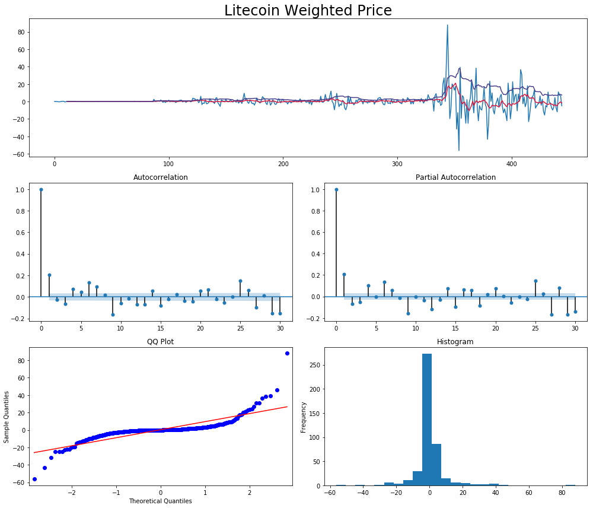

```
Results of Dickey-Fuller test:
test statistic           -5.239203
p-value                   0.000007
# of lags                17.000000
# of observations       427.000000
Critical Value (1%)      -3.445758
Critical Value (5%)      -2.868333
Critical Value (10%)     -2.570388
dtype: float64
```

```python
wp_ltc_diff = np.diff(wp_ltc)

ts_diagnostics(wp_ltc_diff, lags=30, title='Litecoin Weighted Price')
```

## Litecoin: Decomposition

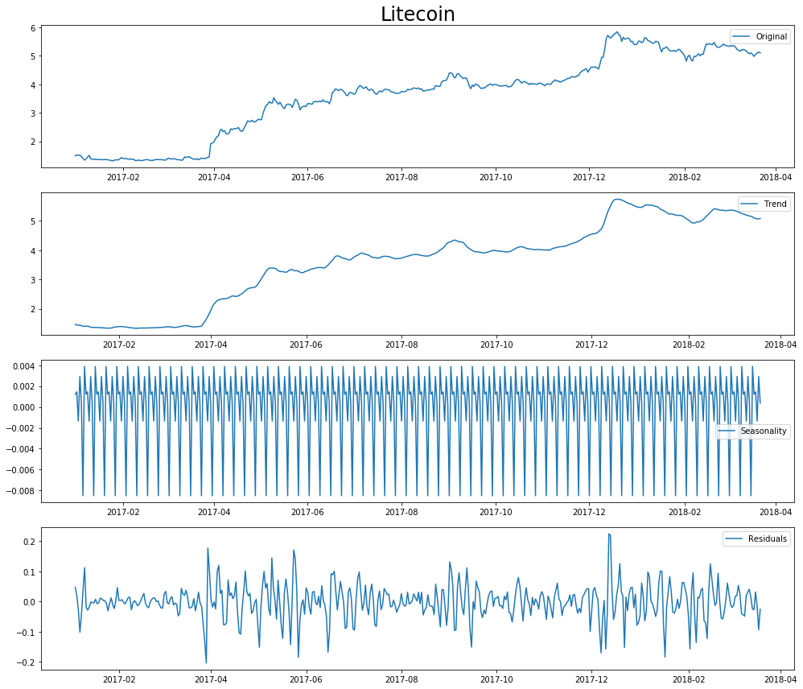

```python
wp_ltc_log = np.log(wp_ltc)

ts_decomposition(wp_ltc_log, title='Litecoin')
```

**Test of stationarity using time-series residual**

```python
ltc_decomposition = seasonal_decompose(wp_ltc_log)
ltc_residual = ltc_decomposition.resid

wp_ltc_log_decompose = ltc_residual
wp_ltc_log_decompose.dropna(inplace=True)
test_stationarity(wp_ltc_log_decompose)
```

```
Results of Dickey-Fuller Test:
Test Statistic                -9.100540e+00
p-value                        3.615751e-15
#Lags Used                     1.400000e+01
Number of Observations Used    4.250000e+02
Critical Value (1%)           -3.445831e+00
Critical Value (5%)           -2.868365e+00
Critical Value (10%)          -2.570405e+00
dtype: float64
```